# Observation Error Model

# Examples

Create an index aggregated over ages

```r
apply(oem(ple4),2,sum)
```

```
, , unit = unique, season = all, area = unique

     year
age   1957   1958   1959   1960   1961
  all 291997 274840 297378 318346 340461

      [ ...  42 years]

     year
age   2004   2005   2006   2007   2008
  all 183865 178143 221323 194610 269540
```

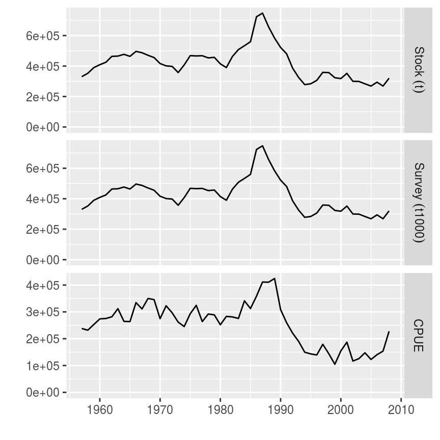

```r
plot(FLQuants(ple4,"Stock"=stock,
                   "Survey"=function(x) apply(survey(x,timing=0,mass=TRUE),2,sum),
                   "CPUE"  =function(x) apply(  cpue(x),2,sum)))
```

The age structure can be shaped by `sel`, e.g. for a survey of mature individuals

```r
ggplot(apply(survey(ple4,sel=mat(ple4)),2,sum))
```

[output not shown]

```r
ggplot(apply(survey(ple4,sel=mat(ple4)),2,sum))
```

[output not shown]

## Uncertainty

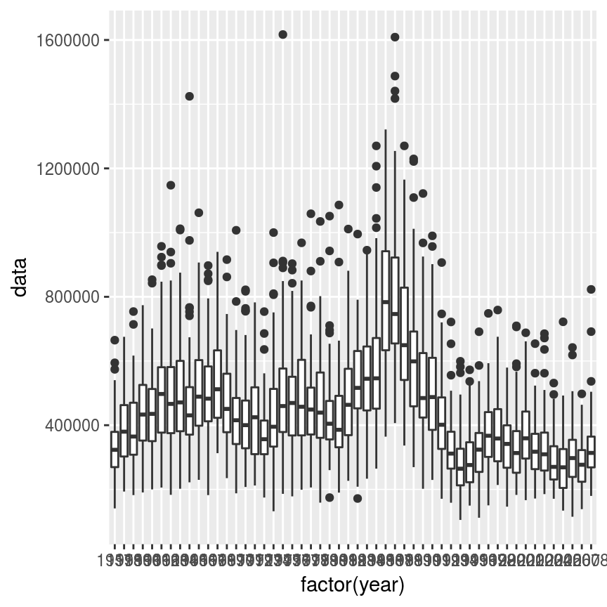

```r
cv=rlnorm(100,log(stock(ple4)),0.3)
ggplot(cv)+
  geom_boxplot(aes(factor(year),data))
```

## Age structure

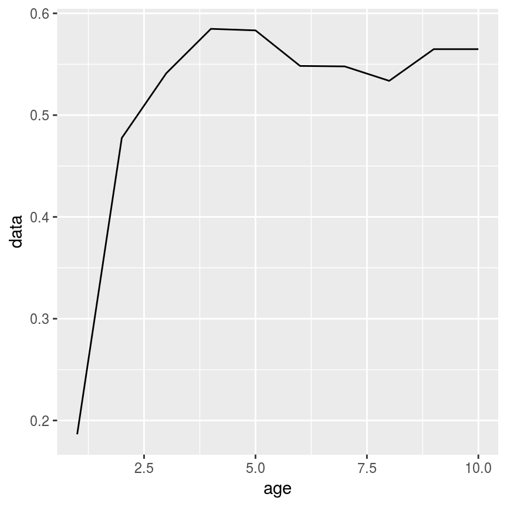

```r
sel  =apply(harvest(ple4),1,mean)
ggplot(sel)+
  geom_line(aes(age,data))
```

## Trends

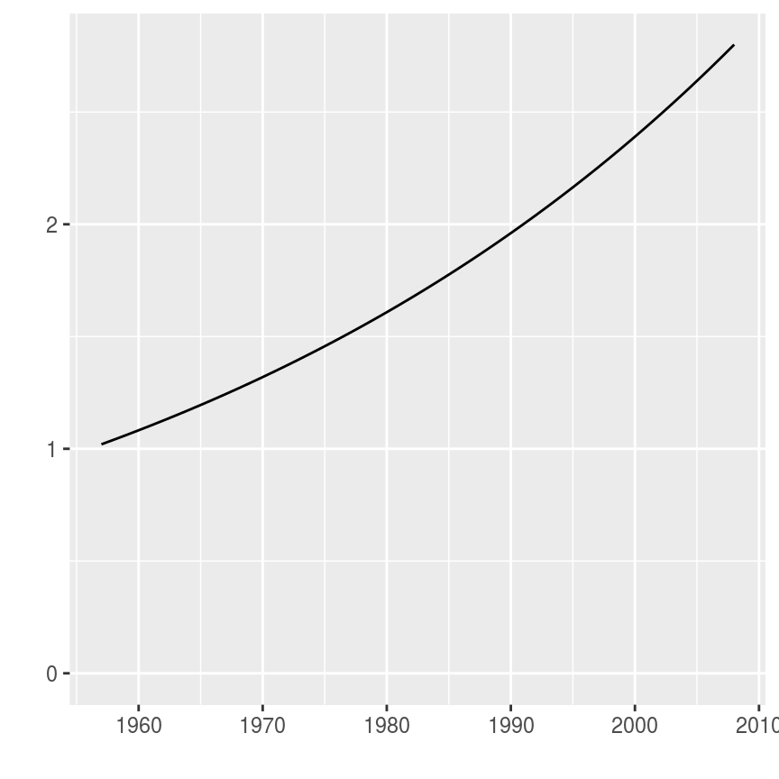

```r
q    =FLQuant(cumprod(1+rep(.02,dim(fbar(ple4))[2])),dimnames=dimnames(fbar(ple4)))
plot(q)
```

## Hyperstability

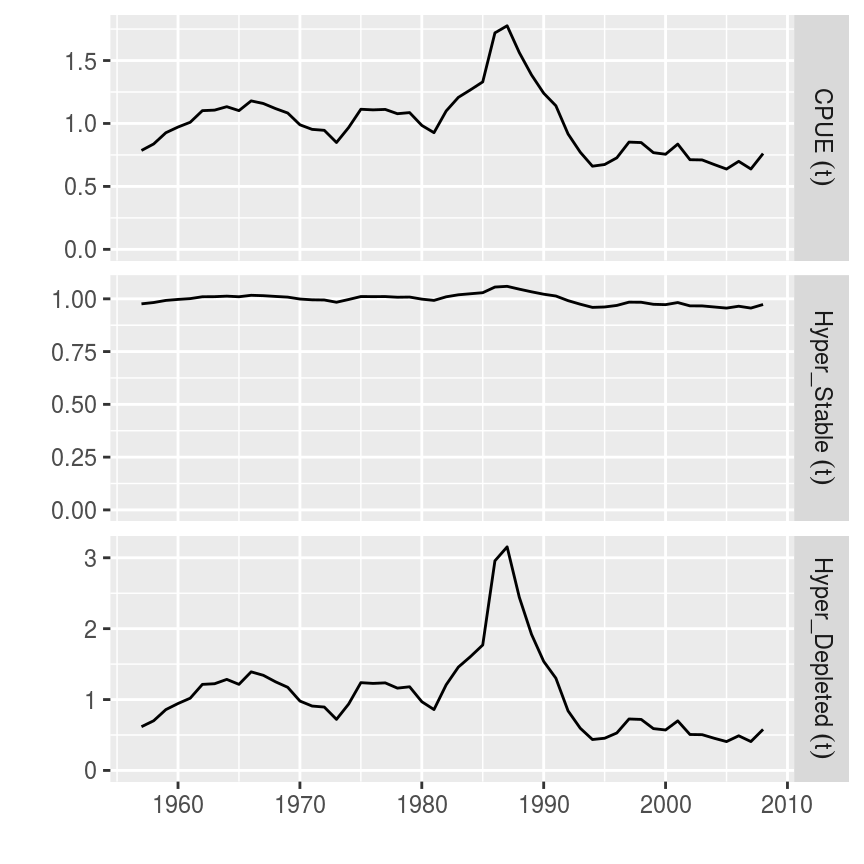

```r
cpue   =stock(ple4)/mean(stock(ple4))
stable =cpue^0.1
deplete=cpue^2

plot(FLQuants("CPUE"          =cpue,
              `Hyper_Stable`  =stable,
              `Hyper_Depleted`=deplete))
```

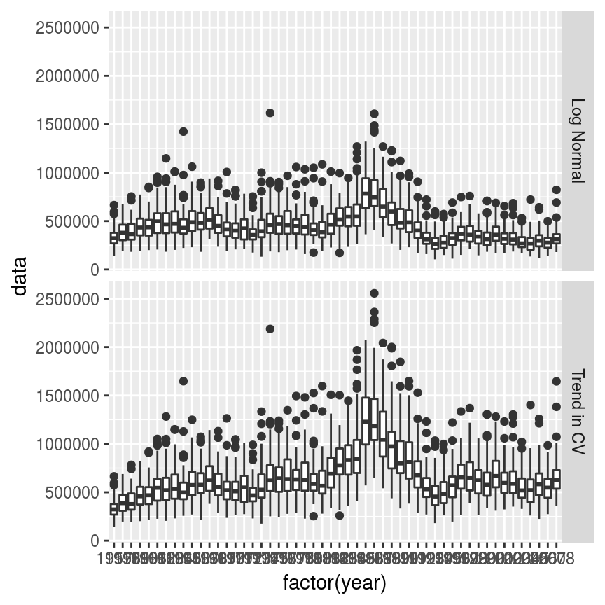

```r
trend=FLQuant(seq(1,2,length.out=dim(stock(ple4))[2]),dimnames=dimnames(stock(ple4)))
var  =trend*abs(cv)*sign(cv)

ggplot(FLQuants("Log Normal" =cv,
                "Trend in CV"=var))+
  geom_boxplot(aes(factor(year),data))+
  facet_grid(qname~.)
```

```r
bias=FLPar(omega=1,ref=mean(stock(ple4)),q=0)

hyperstability<-function(object,omega=1,ref=apply(object,c(1,3:6),mean))
  ref%*%((object%/%ref)^omega)

bias<-function(object,bias=0.02)
     FLQuant(cumprod(1+rep(bias,dim(object)[2])),dimnames=dimnames(object))
```

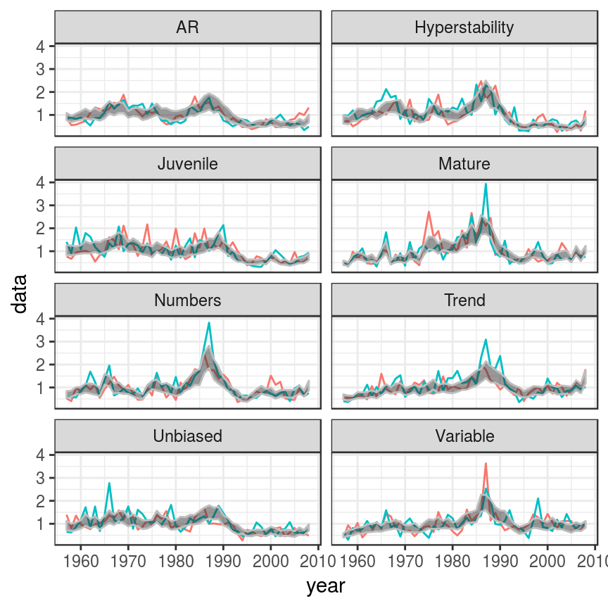

```r
set.seed(1234)
u     =FLQuants("Unbiased"      =rlnorm(100,log(apply(oem(ple4),2:6,sum)),.3),
                "Hyperstability"=rlnorm(100,log(apply(oem(ple4),2:6,sum)%*%
                                                  hyperstability(stock(ple4),0.52)),.3),
                "Trend"         =rlnorm(100,log(apply(oem(ple4),2:6,sum)%*%bias(stock(ple4),0.02)),.3),
                "AR"            =apply(oem(ple4),2:6,sum)%*%
                                   exp(rnoise(100,apply(oem(ple4),2:6,sum)*0,.3,b=.7)),
                "Variable"      =var,
                "Juvenile"      =rlnorm(100,log(apply(oem(ple4,sel=mat(ple4)),2:6,sum)),.3),
                "Mature"        =rlnorm(100,log(apply(oem(ple4,sel=1-mat(ple4)),2:6,sum)),.3),
                "Numbers"       =rlnorm(100,log(apply(oem(ple4,mass=FALSE),2:6,sum)),.3))

u=FLQuants(llply(u,function(x) x/mean(x)))
u=ldply(u,as.data.frame)

u.=ddply(u,.(year,.id), with, quantile(data))
ggplot()+
  geom_line(aes(year,data,col=factor(iter)),
            data=subset(u,iter%in%c(2,11)))+
  geom_ribbon(aes(year,ymin=`25%`,ymax=`75%`),data=u.,col="grey",alpha=.5)+
  facet_wrap(~.id,ncol=2)+
  theme_bw()+theme(legend.position="none")
```

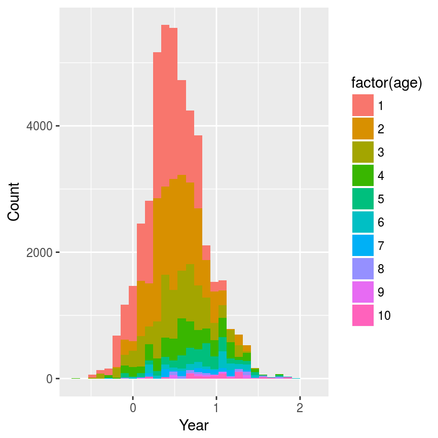

```r
library(FLCore)
library(ggplotFL)
library(tmvtnorm)
library(plyr)
library(reshape2)

data(ple4)

n =survey(ple4)
n =round(1000*n%/%apply(n,2:6,sum))
l =stock.wt(ple4)^0.3

sigma=FLPar(0,dimnames=dimnames(n)[c(1,1:6)])
sigma=apply(sigma,3:7,function(x) {diag(x)=0.2;x})
sigma=FLPar(c(sigma),dimnames=dimnames(n)[c(1,1:6)])

sigma=FLPar(aperm(maply(dimnames(l)$year, function(year) cor2cov(sigma@.Data[,,year,,,,,drop=T],l[,year])),3:1))
names(dimnames(sigma)[3])="year"

upper=n%=%20

x=rtmvnorm(n=max(n[,1]), mean=c(l[,1]), sigma=matrix(c(sigma[,,1,drop=T]),10,10), upper=c(upper[,1]))
x=melt(x)

names(x)[1:2]=c("iter","age")
n=as.data.frame(n,drop=TRUE)
x =subset(merge(n,x),iter<=data)

ggplot(x)+
  geom_histogram(aes(value,fill=factor(age)))+
  xlab("Year")+ylab("Count")
```

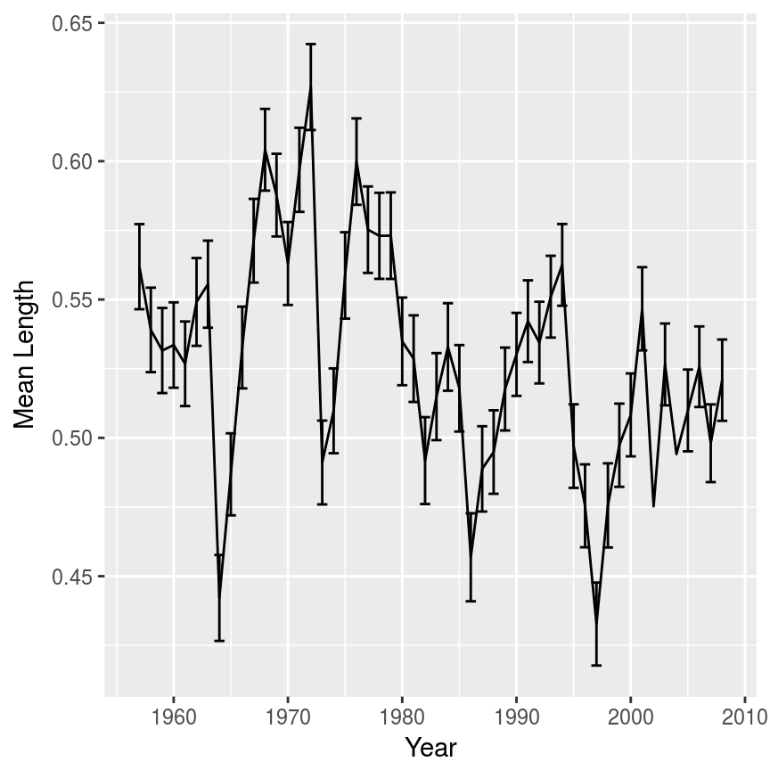

```r
library(FLCore)
library(tmvtnorm)
library(reshape2)

lem2<-function(n,l,sd){

  se=sd/n^0.5
  se=(apply(se%*%se%*%n,c(2:6),sum)%/%apply(n,2:6,sum))^0.5

  ln=apply(l%*%n,2:6,sum)%/%apply(n,2:6,sum)

  FLQuants(len=ln,se=se)}

data(ple4)

n =survey(ple4)
n =round(1000*n%/%apply(n,2:6,sum))
l =stock.wt(ple4)^0.3
sd=l*0.2

lengths=lem2(n,l,sd)

ggplot()+
  geom_line(aes(year,data),data=as.data.frame(lengths[[1]]))+
  geom_errorbar(aes(year,ymin=min,ymax=max),
                data=model.frame(FLQuants(
                         min=lengths[[1]]-lengths[[2]],
                         max=lengths[[1]]+lengths[[2]])))+
  xlab("Year")+ylab("Mean Length")
```

Back to Top

More information

```r
    library(devtools)
    install_github('flr/FLPKG')
```

## Author information

**Laurence KELL**. laurie.kell.es

## Acknowledgements

This vignette and many of the methods documented in it were developed under the MyDas project funded by the Irish exchequer and EMFF 2014-2020. The overall aim of MyDas is to develop and test a range of assessment models and methods to establish Maximum Sustainable Yield (MSY) reference points (or proxy MSY reference points) across the spectrum of data-limited stocks.

# References

Back to Top

[^1]: Wilkinson, L. 1999. *The Grammar of Graphics*, Springer. [doi 10.1007/978-3-642-21551-3_13](http://dx.doi.org/10.1007/978-3-642-21551-3_13).
[^2]: http://tutorials.iq.harvard.edu/R/Rgraphics/Rgraphics.html
[^3]: https://github.com/flr/FLPKG/issues
[^4]: http://flr-project.org